# Reproducible Research: Peer Assessment 1

## Setting Global Options

```r
library(knitr)
opts_chunk$set(echo = TRUE, results = 'asis', warning = FALSE)
```

## 1. Loading and preprocessing the data

### 1.1 Check if the directory exists

```r
if (!file.exists("Dataset")) {
    dir.create("Dataset")
}
```

### 1.2 Download the data into directory

```r
Url = "https://d396qusza40orc.cloudfront.net/repdata%2Fdata%2Factivity.zip"
download.file(Url, destfile = "./Dataset/stepsData.zip")
```

### 1.3 Unzip the dataset

```r
unzip(zipfile = "./Dataset/stepsData.zip",
      exdir = "./Dataset")
```

### 1.4 Load the data into R

```r
activity <- read.csv("./Dataset/activity.csv")
library(xtable)
head <- xtable(head(activity))
print(head, type = "html")
```

|  | steps | date | interval |
| --- | --- | --- | --- |
| 1 |  | 2012-10-01 | 0 |
| 2 |  | 2012-10-01 | 5 |
| 3 |  | 2012-10-01 | 10 |
| 4 |  | 2012-10-01 | 15 |
| 5 |  | 2012-10-01 | 20 |
| 6 |  | 2012-10-01 | 25 |

## 2. What is mean total number of steps taken per day?

### 2.1 Calculate the total number of steps taken per day

```r
total_steps_per_day <- with(activity, aggregate(steps, by = list(date), sum, na.rm = TRUE))

total_steps_per_day <- xtable(total_steps_per_day)
print(total_steps_per_day, type = "html")
```

|  | Group.1 | x |
| --- | --- | --- |
| 1 | 2012-10-01 | 0 |
| 2 | 2012-10-02 | 126 |
| 3 | 2012-10-03 | 11352 |
| 4 | 2012-10-04 | 12116 |
| 5 | 2012-10-05 | 13294 |
| 6 | 2012-10-06 | 15420 |
| 7 | 2012-10-07 | 11015 |
| 8 | 2012-10-08 | 0 |
| 9 | 2012-10-09 | 12811 |
| 10 | 2012-10-10 | 9900 |
| 11 | 2012-10-11 | 10304 |
| 12 | 2012-10-12 | 17382 |
| 13 | 2012-10-13 | 12426 |
| 14 | 2012-10-14 | 15098 |
| 15 | 2012-10-15 | 10139 |
| 16 | 2012-10-16 | 15084 |
| 17 | 2012-10-17 | 13452 |
| 18 | 2012-10-18 | 10056 |
| 19 | 2012-10-19 | 11829 |
| 20 | 2012-10-20 | 10395 |
| 21 | 2012-10-21 | 8821 |
| 22 | 2012-10-22 | 13460 |
| 23 | 2012-10-23 | 8918 |
| 24 | 2012-10-24 | 8355 |
| 25 | 2012-10-25 | 2492 |
| 26 | 2012-10-26 | 6778 |
| 27 | 2012-10-27 | 10119 |
| 28 | 2012-10-28 | 11458 |
| 29 | 2012-10-29 | 5018 |
| 30 | 2012-10-30 | 9819 |
| 31 | 2012-10-31 | 15414 |
| 32 | 2012-11-01 | 0 |
| 33 | 2012-11-02 | 10600 |
| 34 | 2012-11-03 | 10571 |
| 35 | 2012-11-04 | 0 |
| 36 | 2012-11-05 | 10439 |
| 37 | 2012-11-06 | 8334 |
| 38 | 2012-11-07 | 12883 |
| 39 | 2012-11-08 | 3219 |
| 40 | 2012-11-09 | 0 |
| 41 | 2012-11-10 | 0 |
| 42 | 2012-11-11 | 12608 |
| 43 | 2012-11-12 | 10765 |
| 44 | 2012-11-13 | 7336 |
| 45 | 2012-11-14 | 0 |
| 46 | 2012-11-15 | 41 |
| 47 | 2012-11-16 | 5441 |
| 48 | 2012-11-17 | 14339 |
| 49 | 2012-11-18 | 15110 |
| 50 | 2012-11-19 | 8841 |
| 51 | 2012-11-20 | 4472 |
| 52 | 2012-11-21 | 12787 |
| 53 | 2012-11-22 | 20427 |
| 54 | 2012-11-23 | 21194 |
| 55 | 2012-11-24 | 14478 |
| 56 | 2012-11-25 | 11834 |
| 57 | 2012-11-26 | 11162 |
| 58 | 2012-11-27 | 13646 |
| 59 | 2012-11-28 | 10183 |
| 60 | 2012-11-29 | 7047 |
| 61 | 2012-11-30 | 0 |

### 2.1.1 Changing the column names for total_steps_per_day

```r
names(total_steps_per_day) <- c("Date", "Steps")

total_steps_per_day <- xtable(total_steps_per_day)
print(total_steps_per_day, type = "html")
```

|  | Date | Steps |
| --- | --- | --- |
| 1 | 2012-10-01 | 0 |
| 2 | 2012-10-02 | 126 |
| 3 | 2012-10-03 | 11352 |
| 4 | 2012-10-04 | 12116 |
| 5 | 2012-10-05 | 13294 |
| 6 | 2012-10-06 | 15420 |
| 7 | 2012-10-07 | 11015 |
| 8 | 2012-10-08 | 0 |
| 9 | 2012-10-09 | 12811 |
| 10 | 2012-10-10 | 9900 |
| 11 | 2012-10-11 | 10304 |
| 12 | 2012-10-12 | 17382 |
| 13 | 2012-10-13 | 12426 |
| 14 | 2012-10-14 | 15098 |
| 15 | 2012-10-15 | 10139 |
| 16 | 2012-10-16 | 15084 |
| 17 | 2012-10-17 | 13452 |
| 18 | 2012-10-18 | 10056 |
| 19 | 2012-10-19 | 11829 |
| 20 | 2012-10-20 | 10395 |
| 21 | 2012-10-21 | 8821 |
| 22 | 2012-10-22 | 13460 |
| 23 | 2012-10-23 | 8918 |
| 24 | 2012-10-24 | 8355 |
| 25 | 2012-10-25 | 2492 |
| 26 | 2012-10-26 | 6778 |
| 27 | 2012-10-27 | 10119 |
| 28 | 2012-10-28 | 11458 |
| 29 | 2012-10-29 | 5018 |
| 30 | 2012-10-30 | 9819 |
| 31 | 2012-10-31 | 15414 |
| 32 | 2012-11-01 | 0 |
| 33 | 2012-11-02 | 10600 |
| 34 | 2012-11-03 | 10571 |
| 35 | 2012-11-04 | 0 |
| 36 | 2012-11-05 | 10439 |
| 37 | 2012-11-06 | 8334 |
| 38 | 2012-11-07 | 12883 |
| 39 | 2012-11-08 | 3219 |
| 40 | 2012-11-09 | 0 |
| 41 | 2012-11-10 | 0 |
| 42 | 2012-11-11 | 12608 |
| 43 | 2012-11-12 | 10765 |
| 44 | 2012-11-13 | 7336 |
| 45 | 2012-11-14 | 0 |
| 46 | 2012-11-15 | 41 |
| 47 | 2012-11-16 | 5441 |
| 48 | 2012-11-17 | 14339 |
| 49 | 2012-11-18 | 15110 |
| 50 | 2012-11-19 | 8841 |
| 51 | 2012-11-20 | 4472 |
| 52 | 2012-11-21 | 12787 |
| 53 | 2012-11-22 | 20427 |
| 54 | 2012-11-23 | 21194 |
| 55 | 2012-11-24 | 14478 |
| 56 | 2012-11-25 | 11834 |
| 57 | 2012-11-26 | 11162 |
| 58 | 2012-11-27 | 13646 |
| 59 | 2012-11-28 | 10183 |
| 60 | 2012-11-29 | 7047 |
| 61 | 2012-11-30 | 0 |

### 2.2 Make a histogram of the total number of steps taken each day

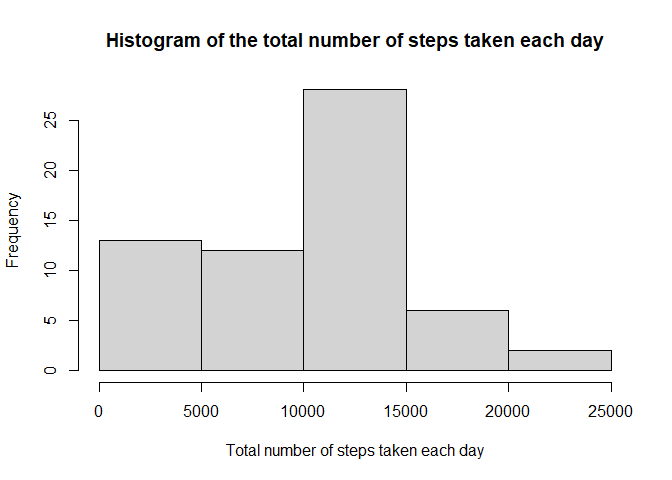

```r
hist(total_steps_per_day$Steps,
     main = "Histogram of the total number of steps taken each day",
     xlab = "Total number of steps taken each day")
```

### 2.3 Calculate and report the mean and median of the total number of steps taken per day

The mean of the total number of steps taken per day is:

```r
mean(total_steps_per_day$Steps)
```

[1] 9354.23

The median of the total number of steps taken per day is:

```r
median(total_steps_per_day$Steps)
```

[1] 10395

## 3. What is the average daily activity pattern?

### 3.1 Make a time series plot (i.e. type = “l”) of the 5-minute interval (x-axis) and the average number of steps taken, averaged across all days (y-axis)

```r
average_steps_per_interval <- with(activity, aggregate(steps, by = list(interval), mean, na.rm = TRUE))

average_steps_per_interval <- xtable(average_steps_per_interval)
print(average_steps_per_interval, type = "html")
```

|  | Group.1 | x |
| --- | --- | --- |
| 1 | 0 | 1.72 |
| 2 | 5 | 0.34 |
| 3 | 10 | 0.13 |
| 4 | 15 | 0.15 |
| 5 | 20 | 0.08 |
| 6 | 25 | 2.09 |
| 7 | 30 | 0.53 |
| 8 | 35 | 0.87 |
| 9 | 40 | 0.00 |
| 10 | 45 | 1.47 |
| 11 | 50 | 0.30 |
| 12 | 55 | 0.13 |
| 13 | 100 | 0.32 |
| 14 | 105 | 0.68 |
| 15 | 110 | 0.15 |
| 16 | 115 | 0.34 |
| 17 | 120 | 0.00 |
| 18 | 125 | 1.11 |
| 19 | 130 | 1.83 |
| 20 | 135 | 0.17 |
| 21 | 140 | 0.17 |
| 22 | 145 | 0.38 |
| 23 | 150 | 0.26 |
| 24 | 155 | 0.00 |
| 25 | 200 | 0.00 |
| 26 | 205 | 0.00 |
| 27 | 210 | 1.13 |
| 28 | 215 | 0.00 |
| 29 | 220 | 0.00 |
| 30 | 225 | 0.13 |

[output cut: 258 more lines]

### 3.1.1 Changing the column names for average_steps_per_interval

```r
names(average_steps_per_interval) <- c("Interval", "Steps")

average_steps_per_interval <- xtable(average_steps_per_interval)
print(average_steps_per_interval, type = "html")
```

|  | Interval | Steps |
| --- | --- | --- |
| 1 | 0 | 1.72 |
| 2 | 5 | 0.34 |
| 3 | 10 | 0.13 |
| 4 | 15 | 0.15 |
| 5 | 20 | 0.08 |
| 6 | 25 | 2.09 |
| 7 | 30 | 0.53 |
| 8 | 35 | 0.87 |
| 9 | 40 | 0.00 |
| 10 | 45 | 1.47 |
| 11 | 50 | 0.30 |
| 12 | 55 | 0.13 |
| 13 | 100 | 0.32 |
| 14 | 105 | 0.68 |
| 15 | 110 | 0.15 |
| 16 | 115 | 0.34 |
| 17 | 120 | 0.00 |
| 18 | 125 | 1.11 |
| 19 | 130 | 1.83 |
| 20 | 135 | 0.17 |
| 21 | 140 | 0.17 |
| 22 | 145 | 0.38 |
| 23 | 150 | 0.26 |
| 24 | 155 | 0.00 |
| 25 | 200 | 0.00 |
| 26 | 205 | 0.00 |
| 27 | 210 | 1.13 |
| 28 | 215 | 0.00 |
| 29 | 220 | 0.00 |
| 30 | 225 | 0.13 |

[output cut: 258 more lines]

### 3.1.2 Time series plot of the 5-minute interval and the average number of steps taken, averaged across all days.

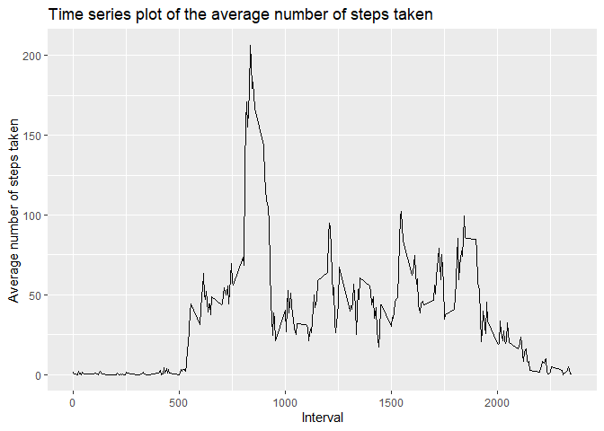

```r
library(ggplot2)
ggplot(data = average_steps_per_interval, aes(x = Interval, y = Steps)) +
    geom_line() +
    ggtitle("Time series plot of the average number of steps taken") +
    xlab("Interval") +
    ylab("Average number of steps taken")
```

### 3.2 Which 5-minute interval, on average across all the days in the dataset, contains the maximum number of steps?

The 5-minute interval which contains the maximum number of steps, on average across all the days in the dataset is:

```r
average_steps_per_interval[which.max(average_steps_per_interval$Steps), ]$Interval
```

[1] 835

## 4. Imputing missing values

### 4.1 Calculate and report the total number of missing values in the dataset (i.e. the total number of rows with NAs)

Total number of rows with NAs:

```r
sum(is.na(activity$steps))
```

[1] 2304

### 4.2 Devise a strategy for filling in all of the missing values in the dataset. The strategy does not need to be sophisticated. For example, you could use the mean/median for that day, or the mean for that 5-minute interval, etc.

```r
mean <- mean(average_steps_per_interval$Steps)
print(mean)
```

[1] 37.3826

### 4.3 Create a new dataset that is equal to the original dataset but with the missing data filled in.

### 4.3.1 Transforming steps column in activity table with the mean if they are NAs

```r
new_activity <- transform(activity,
                              steps = ifelse(is.na(activity$steps),
                                             yes = mean,
                                             no = activity$steps))

head <- xtable(head(new_activity))
print(head, type = "html")
```

|  | steps | date | interval |
| --- | --- | --- | --- |
| 1 | 37.38 | 2012-10-01 | 0 |
| 2 | 37.38 | 2012-10-01 | 5 |
| 3 | 37.38 | 2012-10-01 | 10 |
| 4 | 37.38 | 2012-10-01 | 15 |
| 5 | 37.38 | 2012-10-01 | 20 |
| 6 | 37.38 | 2012-10-01 | 25 |

### 4.4 Make a histogram of the total number of steps taken each day and Calculate and report the mean and median total number of steps taken per day. Do these values differ from the estimates from the first part of the assignment? What is the impact of imputing missing data on the estimates of the total daily number of steps?

### 4.4.1 Calculate the total number of steps taken per day after imputing the missing values

```r
new_total_steps_per_day <- aggregate(steps ~ date, new_activity, sum)

new_total_steps_per_day <- xtable(new_total_steps_per_day)
print(new_total_steps_per_day, type = "html")
```

|  | date | steps |
| --- | --- | --- |
| 1 | 2012-10-01 | 10766.19 |
| 2 | 2012-10-02 | 126.00 |
| 3 | 2012-10-03 | 11352.00 |
| 4 | 2012-10-04 | 12116.00 |
| 5 | 2012-10-05 | 13294.00 |
| 6 | 2012-10-06 | 15420.00 |
| 7 | 2012-10-07 | 11015.00 |
| 8 | 2012-10-08 | 10766.19 |
| 9 | 2012-10-09 | 12811.00 |
| 10 | 2012-10-10 | 9900.00 |
| 11 | 2012-10-11 | 10304.00 |
| 12 | 2012-10-12 | 17382.00 |
| 13 | 2012-10-13 | 12426.00 |
| 14 | 2012-10-14 | 15098.00 |
| 15 | 2012-10-15 | 10139.00 |
| 16 | 2012-10-16 | 15084.00 |
| 17 | 2012-10-17 | 13452.00 |
| 18 | 2012-10-18 | 10056.00 |
| 19 | 2012-10-19 | 11829.00 |
| 20 | 2012-10-20 | 10395.00 |
| 21 | 2012-10-21 | 8821.00 |
| 22 | 2012-10-22 | 13460.00 |
| 23 | 2012-10-23 | 8918.00 |
| 24 | 2012-10-24 | 8355.00 |
| 25 | 2012-10-25 | 2492.00 |
| 26 | 2012-10-26 | 6778.00 |
| 27 | 2012-10-27 | 10119.00 |
| 28 | 2012-10-28 | 11458.00 |
| 29 | 2012-10-29 | 5018.00 |
| 30 | 2012-10-30 | 9819.00 |
| 31 | 2012-10-31 | 15414.00 |
| 32 | 2012-11-01 | 10766.19 |
| 33 | 2012-11-02 | 10600.00 |
| 34 | 2012-11-03 | 10571.00 |
| 35 | 2012-11-04 | 10766.19 |
| 36 | 2012-11-05 | 10439.00 |
| 37 | 2012-11-06 | 8334.00 |
| 38 | 2012-11-07 | 12883.00 |
| 39 | 2012-11-08 | 3219.00 |
| 40 | 2012-11-09 | 10766.19 |
| 41 | 2012-11-10 | 10766.19 |
| 42 | 2012-11-11 | 12608.00 |
| 43 | 2012-11-12 | 10765.00 |
| 44 | 2012-11-13 | 7336.00 |
| 45 | 2012-11-14 | 10766.19 |
| 46 | 2012-11-15 | 41.00 |
| 47 | 2012-11-16 | 5441.00 |
| 48 | 2012-11-17 | 14339.00 |
| 49 | 2012-11-18 | 15110.00 |
| 50 | 2012-11-19 | 8841.00 |
| 51 | 2012-11-20 | 4472.00 |
| 52 | 2012-11-21 | 12787.00 |
| 53 | 2012-11-22 | 20427.00 |
| 54 | 2012-11-23 | 21194.00 |
| 55 | 2012-11-24 | 14478.00 |
| 56 | 2012-11-25 | 11834.00 |
| 57 | 2012-11-26 | 11162.00 |
| 58 | 2012-11-27 | 13646.00 |
| 59 | 2012-11-28 | 10183.00 |
| 60 | 2012-11-29 | 7047.00 |
| 61 | 2012-11-30 | 10766.19 |

### 4.4.2 Make a histogram of the total number of steps taken each day

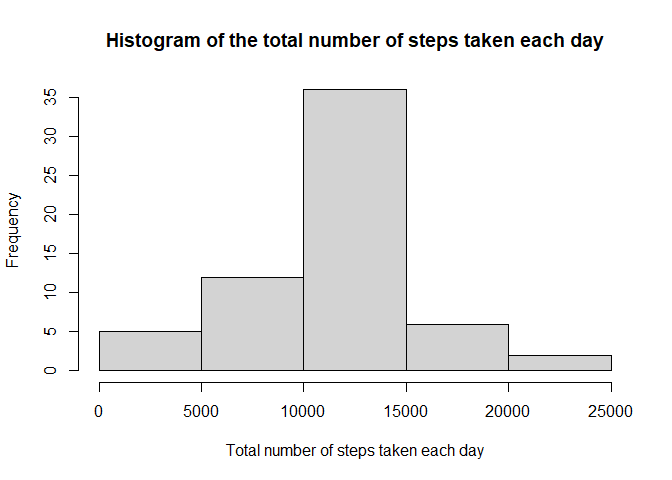

```r
hist(new_total_steps_per_day$steps,
     main = "Histogram of the total number of steps taken each day",
     xlab = "Total number of steps taken each day")
```

### 4.4.3 Calculate and report the mean and median of the total number of steps taken per day

The mean of the total number of steps taken per day is:

```r
mean(new_total_steps_per_day$steps)
```

[1] 10766.19

The median of the total number of steps taken per day is:

```r
median(new_total_steps_per_day$steps)
```

[1] 10766.19

### 4.4.4 Do these values differ from the estimates from the first part of the assignment?

The mean and median of these values are greater than the estimates from the first part of the assignment.

|  | Missing | No_Missing |
| --- | --- | --- |
| Mean | 9354.23 | 10766.19 |
| Median | 10395 | 10766.19 |

### 4.4.5 What is the impact of imputing missing data on the estimates of the total daily number of steps?

Imputing missing data on the estimates of the total daily number of steps will make the numbers appear greater than what they actually are.

## 5. Are there differences in activity patterns between weekdays and weekends?

### 5.1 Create a new factor variable in the dataset with two levels – “weekday” and “weekend” indicating whether a given date is a weekday or weekend day.

### 5.1.1 Change the format of the date variable in the new_activity table

```r
new_activity$date <- as.Date(new_activity$date)
```

### 5.1.2 Create a new factor variable in the dataset with two levels – “weekday” and “weekend”

```r
weekday <- c("Monday", "Tuesday", "Wednesday", "Thursday", "Friday")
new_activity$wkDays <- factor((weekdays(new_activity$date) %in% weekday),
                          levels = c(FALSE, TRUE), labels = c("weekend", "weekday"))

head <- xtable(head(new_activity))
print(head, type = "html")
```

|  | steps | date | interval | wkDays |
| --- | --- | --- | --- | --- |
| 1 | 37.38 | 15614.00 | 0 | weekday |
| 2 | 37.38 | 15614.00 | 5 | weekday |
| 3 | 37.38 | 15614.00 | 10 | weekday |
| 4 | 37.38 | 15614.00 | 15 | weekday |
| 5 | 37.38 | 15614.00 | 20 | weekday |
| 6 | 37.38 | 15614.00 | 25 | weekday |

### 5.2 Make a panel plot containing a time series plot (i.e. type = “l”) of the 5-minute interval (x-axis) and the average number of steps taken, averaged across all weekday days or weekend days (y-axis). See the README file in the GitHub repository to see an example of what this plot should look like using simulated data.

[figure not shown]

```r
new_activity$wkDays <- as.factor(new_activity$wkDays)

ggplot(data = new_activity, aes(x = interval, y = steps)) +
    geom_line() +
    facet_grid(wkDays ~ .) +
    ggtitle("Panel plot of the average number of steps taken") +
    xlab("Interval") +
    ylab("Average number of steps taken")
```